# Xue(Tracy) Feng - Text Analysis - Assignment 3

## Text Analysis - Assignment 3

## Sep 22, 2022

##### Extracting Real-Time Tweets about Tech Companies

Extracting text data from various sources is an integral and very valuable part of text analytics. In this assignment, you will extract text from the Twitter API using either the Twitter API or Tweepy (a Python wrapper for the Twitter API). You will need to sign up for a Developer account (Essential level) to access the Twitter API. Note: You do not need to obtain an Academic account with Twitter to complete this assignment. You are welcome to do so, but you can do it with the Essential level.

Below are some resources to get started with the Twitter API. You need to set up a Developer account (Essential access level) to complete the assignment.

Set up a Twitter Developer account for API access: [link](https://developer.twitter.com/en/docs/twitter-api/getting-started/getting-access-to-the-twitter-api)

Making your first request to Twitter API: [link](https://developer.twitter.com/en/docs/tutorials/step-by-step-guide-to-making-your-first-request-to-the-twitter-api-v2)

You must prepare a Jupyter notebook that contains all necessary code as well as Markdown text to explain each question and step of the process below, how it works, and what is happening. You will save the notebook as an HTML report and submit it to Canvas. The script should run without errors. You should use tables and/or visualizations to show your results when appropriate. There should not be any long raw output such as the full JSON response of the results.

### Question 1

##### Extract 100 Tweets in the past 7 days that @mention or hashtag Microsoft, Amazon, and Google (three separate API calls or using OR operator in the query)

```python
import requests
```

```python
def bearer_oauth(r):
    """
    Method required by bearer token authentication.
    """

    r.headers["Authorization"] = "Bearer AAAAAAAAAAAAAAAAAAAAABBnhQEAAAAAmj2TEQaHQWMXQnRUh7U3XkKbrcY%3DB7ojd6P5EYX3JvK3RiPumNBHJA1JO2i4CV4VrhplyoH7BumEVF"
    r.headers["User-Agent"] = "User"
    return r
```

```python
# return the output of the request
def getTweets(url, params, timeout=10):
    return requests.get(url = url,
            auth=bearer_oauth,
            params=params,
            timeout=timeout)
```

```python
### Set base URL and use requests library to issue get request
# GET /2/tweets/search/recent
# The recent search endpoint returns Tweets from the last seven days that match a search query.
url = "https://api.twitter.com/2/tweets/search/recent"
max_results = 100

# 3 params based on what the question asks
param_Amazon = {"query": '@Amazon' or 'Amazon',
                 "max_results": max_results}
param_Google = {"query": '@Google' or 'Google',
                 "max_results": max_results}
param_Microsoft = {"query": '@Microsoft' or 'Microsoft',
                 "max_results": max_results}
```

```python
# Loop through and print text of all tweets
def printTweets(r):
    i = 1
    for each in r.json()["data"]:
        print(f"Tweet: {each['text']}")
        i += 1
        if i > 10:
           break
```

#### The following output for Q1 shows only first 10 lines

#### 100 Tweets in the past 7 days that @mention or hashtag Amazon

```python
# first 10 lines
rA = getTweets(url, param_Amazon)
printTweets(rA)
```

```
Tweet: 電動鼻水吸引器 NOPPY＋ ノッピープラス NOSE HAPPY ノッピー https://t.co/hFmZXwv48B @amazonより
Tweet: RT @OriginalFunko: RT and follow @OriginalFunko for the chance to WIN the @amazon exclusive Hercules VHS POP! Cover #Funko #FunkoPOP #Givea…
Tweet: モルトベーネ ロレッタ ハードゼリー 300g
どんなスタイルも即キープし、ベタつきの少ないウォーターベースのスタイリングジェル✨
#美男美女さんと繋がりたい

これ一つでばっちりセット決まります💛⬇⬇
https://t.co/7KaeH72lmm @amazonより
Tweet: RT @The_HYKAnime: Plush Pendent for NIJISANJI Luca Kaneshiro Augustus Soft Toy Game Stuffed Decoration 4.3inch https://t.co/5wcQCy98dq #Ama…
Tweet: RT @econliberties: NEWS: Why is it so hard for small businesses to compete with @amazon, @walmart, and other goliaths?

The answer is lax…
Tweet: RT @OriginalFunko: RT and follow @OriginalFunko for the chance to WIN the @amazon exclusive Hercules VHS POP! Cover #Funko #FunkoPOP #Givea…
Tweet: RT @OriginalFunko: RT and follow @OriginalFunko for the chance to WIN the @amazon exclusive Hercules VHS POP! Cover #Funko #FunkoPOP #Givea…
Tweet: @JasonCrownover @amazon @PrimeVideo Nah, all false. They’re paying you to say this. My bro in town can’t watch on his TV either.
Tweet: RT @OriginalFunko: RT and follow @OriginalFunko for the chance to WIN the @amazon exclusive Hercules VHS POP! Cover #Funko #FunkoPOP #Givea…
Tweet: Christmas Decorations Outdoor Star Lights
Original Price:$23.99
Deal Price:$11.99
Code:6YV8XWRZ
Code for this option only
Discount: 50% off
Christmas Decorations Outdoor Star Lights ,16.4Ft  https://t.co/lQTZxeMk83 via @amazon
```

#### 100 Tweets in the past 7 days that @mention or hashtag Google

```python
rG = getTweets(url, param_Google)
printTweets(rG)
```

```
Tweet: BYE BYE @Google #Survey
Last date - #Nov 1'st

#BBNaija #Crush #instagramdown #justiceforCUgirls #OpIran #PAKvENG #Russia #RussiaInvadedUkraine #VVONSUGUNNASILxBeOnCloud https://t.co/OBiWO3aVpW
Tweet: '구글링=검색'일 정도로 신뢰받는 구글이, 이런 간단한 것도 바로잡지 못한다고요? 이것이 구글코리아의 문제인지 본사까지 연결된 문제인지 궁금하군요.
검색내용과 사진을 일원할 자신이 없으면 검색엔진을 관두시기 바랍니다.
@googlekorea @Google

뷔 - Google 뉴스
https://t.co/mtQcypqrDL… https://t.co/gv5u3oUfv1
Tweet: @Microsoft and @Google should be forced by law to allow customers of their platforms, like Google Cloud and Azure, to be able to set a daily $ limit after which the service cuts. #Microsoft #Azure #GoogleCloud
Tweet: RT @Google: when life gives you a question, search it 🔍🍋
Tweet: @doyouknowdeeway @Google I will recommend you to (skidcracks_) on Instagram he can help
Tweet: RT @Google: when life gives you a question, search it 🔍🍋
Tweet: RT @Pitoloco2021: «ÚLTIMA HORA: ¡Después de haber sido baneados por
.@PayPal y .@Venmo hace menos de 24 horas, ACABAMOS de ser baneados po…
Tweet: @Google When life gives gives you a lemon, Make A Lemonade 🙌
Tweet: @Google https://t.co/N8tBgKCkVe
Tweet: RT @againstgrmrs: BREAKING: After being banned by @PayPal and @Venmo less than 24 hours ago, We have JUST been banned by @Google!

Big tec…
```

#### 100 Tweets in the past 7 days that @mention or hashtag Microsoft

```python
rM = getTweets(url, param_Microsoft)
printTweets(rM)
```

```
Tweet: @Microsoft and @Google should be forced by law to allow customers of their platforms, like Google Cloud and Azure, to be able to set a daily $ limit after which the service cuts. #Microsoft #Azure #GoogleCloud
Tweet: @padrunk_ @Halo @XboxMexico @Microsoft Chales ya me lo esperaba pero igual duele que hagan eso, mejor que se cambien el nombre 343 y ya así en nueva compañía saquen otro
Tweet: Imagine this on Linux if they gave you a spinning wheel for 5 mins when logging in for the first time? Or hang up the machine for 2-3 mins for no reason when rebooting. @Microsoft Steve Jobs called it in the 80s you are just a tastless company.
Tweet: Again I Would Truly Love To See The Following Japanese Company's Be Bought By @Microsoft @Xbox  @XboxP3  @BondSarah_Bond  @MattBooty   🙏🎮❎🖱️   #Sega   #TeamNinja   #FromSoftware   #BandaiNamco https://t.co/5EAVOe3m2Z
Tweet: RT @WNBA: Riquna Williams  was #MoreThan CLUTCH in crunch time of Game 4 of the #WNBAFinals

Her 4th quarter performance earned her a @Micr…
Tweet: RT @GatesMXMX: 🕋 555. (KM) AKERMANN SQUARE | IT’S A SUNSET cc: @JumboPrivacy @Microsoft @Yammer @DavidSacks 🌚🌒🌘🌝 🌐 #SUNSETLABS https://t.co…
Tweet: @motorious_eu @motorious_nyc @Azure @SEMAMembers @here @BoschGlobal @autogradelinux @cariad_tech @WestwoodOne @NOAA @iHeartRadio @MobileE_Group @SAP_Retail @BestBuy @GeekSquad @InstallernetU @Installer_Show @AAPEXShow @Aftermarket_Biz @Canonical @ubuntu @uspto @UbuntuOne @linuxfoundation @mot…
Tweet: @motorious_eu @motorious_nyc @Azure @SEMAMembers @here @BoschGlobal @autogradelinux @cariad_tech @WestwoodOne @NOAA @iHeartRadio @MobileE_Group @SAP_Retail @BestBuy @GeekSquad @InstallernetU @Installer_Show @AAPEXShow @Aftermarket_Biz @Canonical @ubuntu @uspto @UbuntuOne @linuxfoundation @mot…
Tweet: @Greg012094 @AP @BillGates @melindagates @celtics @Microsoft Fair enough. I opine that they stand to lose a lot more if the coach walks away. Udoka is a young head coach - with stints in great NBA programs - overseeing a relatively young team that has bought into his style. Continuity eventua…
Tweet: @bookpublish101 @Microsoft https://t.co/msFGM1hyMN  take  a look
```

### Question 2

##### Parse the results and create a dataframe that contains the raw text of the tweets. Process the text so that only lowercase letters remain.

```python
import pandas as pd
import numpy as np
import re
```

```python
# combine 3 tweet output from Q2 into one df
tweets = [each["text"] for each in rA.json()["data"]] + \
         [each["text"] for each in rG.json()["data"]] + \
         [each["text"] for each in rM.json()["data"]]
```

```python
tweets_data = pd.DataFrame({"tweets": tweets})
```

```python
tweets_data[["tweets"]].info()
```

```
<class 'pandas.core.frame.DataFrame'>
RangeIndex: 298 entries, 0 to 297
Data columns (total 1 columns):
 #   Column  Non-Null Count  Dtype
---  ------  --------------  -----
 0   tweets  298 non-null    object
dtypes: object(1)
memory usage: 2.5+ KB
```

```python
# text cleaning
def process_tweets(t):

    t = t.lower()
    t = re.sub("@[A-Za-z0-9]+", "", t) # remove handles
    t = re.sub("#[A-Za-z0-9]+", "", t) # remove hashtags
    t = re.sub(r"http\S+", "", t)      # remove links (anything that doesn't have a space after http)
    t = re.sub(r"www.\S+", "", t)      # remove links
    t = re.sub("[()!?]", "", t)        # remove punctuation
    t = re.sub("\[.*?\]", "", t)       # remove puncutation
    t = re.sub("[^a-z]", " ", t)
    return t
```

```python
# apply the text cleaning function to the data and generate a new column called "tweets_clean"
tweets_data["tweets_clean"] = tweets_data["tweets"].apply(process_tweets)
```

```python
# drop the original uncleaned column
tweets_data = tweets_data.drop(columns=["tweets"])
```

```python
tweets_data
```

|  | tweets_clean |
| --- | --- |
| 0 | noppy nose happy |
| 1 | rt rt and follow for the chance to win the ... |
| 2 | g ... |
| 3 | rt hykanime plush pendent for nijisanji luca... |
| 4 | rt news why is it so hard for small busines... |
| ... | ... |
| 293 | nexah tech also morrowind was xbox exclusi... |
| 294 | nexah tech xbox player can t even play fin... |
| 295 | i am contacting you regarding an ongoing is... |
| 296 | ab verdansk would be a blessing to pla... |
| 297 | we re looking at you |

298 rows × 1 columns

### Question 3

##### Vectorize the raw text and determine the most frequent single word mentions in tweets for each company. Determine the most frequent two-word phrases mentioned.

```python
from sklearn.feature_extraction.text import CountVectorizer
```

a helper function for getting n-grams

```python
def get_ngrams(text, ngram_from=2, ngram_to=2, n=None, max_features=20000):

    vec = CountVectorizer(ngram_range = (ngram_from, ngram_to),
                          max_features = max_features,
                          stop_words='english').fit(text)
    bag_of_words = vec.transform(text)
    sum_words = bag_of_words.sum(axis = 0)
    words_freq = [(word, sum_words[0, i]) for word, i in vec.vocabulary_.items()]
    words_freq = sorted(words_freq, key = lambda x: x[1], reverse = True)

    return words_freq[:n]
```

```python
# a helper function to vectorize the raw text
def vectorize(d, gram_name, ngram_from=1, ngram_to=1, n = 1):
    unigrams = get_ngrams(d.squeeze(), ngram_from, ngram_to, n=1)
    unigrams_df = pd.DataFrame(unigrams)
    unigrams_df.columns=[gram_name, "Frequency"]
    return unigrams_df.head()
```

```python
vectorize(tweets_data.iloc[:100], "Amazon Unigram")
```

|  | Amazon Unigram | Frequency |
| --- | --- | --- |
| 0 | rt | 76 |

```python
vectorize(tweets_data.iloc[100:200], "Google Unigram")
```

|  | Google Unigram | Frequency |
| --- | --- | --- |
| 0 | rt | 54 |

```python
vectorize(tweets_data.iloc[200:300], "Microsoft Unigram")
```

|  | Microsoft Unigram | Frequency |
| --- | --- | --- |
| 0 | rt | 31 |

```python
vectorize(tweets_data.iloc[:100], "Amazon Two-grams", 2, 2)
```

|  | Amazon Two-grams | Frequency |
| --- | --- | --- |
| 0 | rt rt | 36 |

```python
vectorize(tweets_data.iloc[100:200], "Google Two-grams", 2, 2)
```

|  | Google Two-grams | Frequency |
| --- | --- | --- |
| 0 | rt breaking | 20 |

```python
vectorize(tweets_data.iloc[200:300], "Microsoft Two-grams", 2, 2)
```

|  | Microsoft Two-grams | Frequency |
| --- | --- | --- |
| 0 | rt tech | 5 |

### Question 4

##### Create three plots showing the most frequent single word in the tweets about each company. Create three more plots showing the most frequent two or three word phrases in the tweets about each company.

```python
from wordcloud import WordCloud
import matplotlib.pyplot as plt
```

A helper function to generate a list of words with punctuations removed

```python
def single_word_generator(d):
    all_words = []
    for column_name, s in d.iteritems():
        # split the current sentence
        temp_res = s.str.split()
        # append each word to the list
        for w in temp_res:
            all_words.append(w)
    return all_words
```

A helper function to display a wordcloud

```python
def word_cloud_generator(s):
    wordcloud = WordCloud(background_color="white", width = 1000, height = 500).generate(s)
    plt.figure(figsize=(15,8))
    plt.imshow(wordcloud)
    plt.axis("off")
    plt.savefig("your_file_name"+".png", bbox_inches='tight')
    plt.show()
    plt.close()
```

A helper function to plot the frequency with n-gram(s)

```python
def plot_frequency(df, ngram_min=1, ngram_max=1, n=10):

    n_grams = get_ngrams(df.squeeze(), ngram_from=ngram_min, ngram_to=ngram_max, n=n)
    n_grams_df = pd.DataFrame(n_grams)
    n_grams_df.columns=["Grams", "Frequency"]
    n_grams_df = n_grams_df.sort_values("Frequency", ascending=True)
    plt.barh('Grams', 'Frequency', data=n_grams_df, height = 1, color='orange')
    plt.xlabel('Frequency')
    plt.ylabel('Grams')
    plt.rcParams.update({'font.size': 20})
    return plt.show()
```

Amazon - the most frequent single word in the tweets

### FYI I've tried 10 ways to make the bar look thinner, but none of them worked. If you know, please let me know how you do it... It's way more difficult than I imagine, especially when it has only one single bar. These are the prettiest plots I can make.... =.=

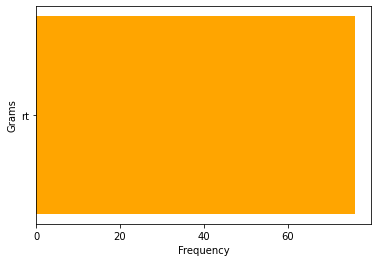

```python
plot_frequency(tweets_data.iloc[:100], 1, 1, 1)
```

Google - the most frequent single word in the tweets

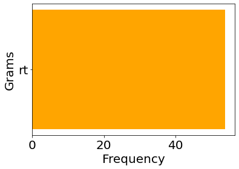

```python
plot_frequency(tweets_data.iloc[100:200], 1, 1, 1)
```

Microsoft - the most frequent single word in the tweets

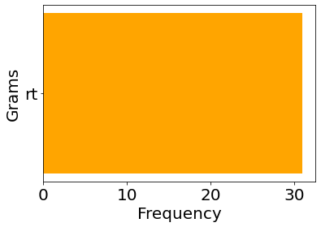

```python
plot_frequency(tweets_data.iloc[200:300], 1, 1, 1)
```

Amazon - the most frequent three word phrases in the tweets

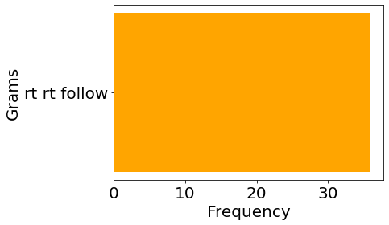

```python
plot_frequency(tweets_data.iloc[:100], 3, 3, 1)
```

Google - the most frequent three word phrases in the tweets

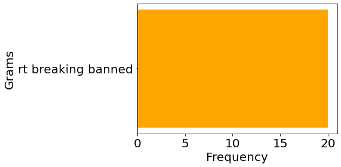

```python
plot_frequency(tweets_data.iloc[100:200], 3, 3, 1)
```

Microsoft - - the most frequent three word phrases in the tweets

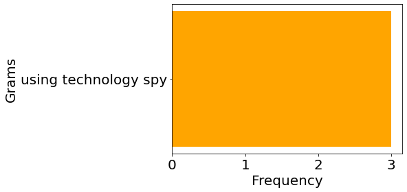

```python
plot_frequency(tweets_data.iloc[200:300], 3, 3, 1)
```

### Question 5

##### Define a user defined function that takes one argument--company name--and returns a dataframe that contains a column of clean (lower case, letters only) text of tweets that @mention or hashtag the company passed to the function.

```python
# combined the seperated code from previous questions into a function
def retrive_tweets(company):
    url = "https://api.twitter.com/2/tweets/search/recent"
    max_results = 100
    param_Amazon = {"query": f'@{company}' or f'#{company}',
                     "max_results": max_results}
    r = getTweets(url, param_Amazon)
    tweets = [each["text"] for each in r.json()["data"]]
    tweets_data = pd.DataFrame({"tweets": tweets})
    tweets_data["tweets_clean"] = tweets_data["tweets"].apply(process_tweets)
    tweets_data = tweets_data.drop(columns=["tweets"])
    return tweets_data
```

```python
# test for Facebook
retrive_tweets('Facebook')
```

|  | tweets_clean |
| --- | --- |
| 0 | jesus man people need to learn how to t... |
| 1 | let s see if i have this straight you re ce... |
| 2 | rt are you helping the totalitarian regim... |
| 3 | keep the ban in place |
| 4 | rt |
| ... | ... |
| 95 | ... |
| 96 | dear amp you ve both successfully locked m... |
| 97 | ... |
| 98 | rt have a responsibility to respect huma... |
| 99 | psa unlink meta accounts if one gets comprom... |

100 rows × 1 columns